# New Wine into Old Wineskins

by Kameron York

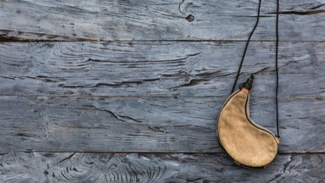

#### Reference:

[Matthew 9:17](https://www.churchofjesuschrist.org/study/scriptures/nt/matt/9?lang=eng&id=17#p17)  
[Mark 2:22](https://www.churchofjesuschrist.org/study/scriptures/nt/mark/2?lang=eng&id=22#p22)  
[Luke 5:37-39](https://www.churchofjesuschrist.org/study/scriptures/nt/luke/5?lang=eng&id=37-39#p37)

#### Insights here:

This parable centers around the idea that new things are not meant to mesh well with old things. All three accounts of this parable focus on the process of making wine.  
The ancient way of making wine included crafting the container out of animal skins (mostly goat skins). After mashing grapes the natural yeast would consume the sugars and create alcohol, releasing gasses as it does. A newly made wineskin would be soft and had enough stretch to expand as these gasses were created. However, an old wineskin was brittle and did not have the same amount of stretch, meaning the gasses from this new wine would cause that old wineskin to burst.  
Matthew’s account of the parable says “bottles” instead of wineskins, but this is likely a difference in translation. Matthew also adds another interesting note in his account. After teaching that new wine would not be put into old bottles, Jesus says, “…and both are preserved.” This line is not found in the other accounts of the parable. I have read some sources that claim this is Jesus teaching that the new bottles and the old bottles are preserved, meaning the Law of Moses and the new Higher Law are meant to coexist. I like this thought, as even Jesus taught that he was not come to destroy the law but to fulfill it. However, I don’t fully agree with this interpretation of the text. The parable follows simple cause and effect:  
1. New wine -> Old bottles = Burst.  
2. New wine -> New bottles = “both preserved”.  
Based on my reading of this parable I believe Jesus is saying that new wine being placed into new bottles means that both the wine and the bottle are preserved, not both types of bottle.  
It is important to note that added context can be gleaned from the Joseph Smith Translation of this passage. Following this parable of the wineskines the pharisees (who’s presence was not noted in any of the accounts) have an exchange with Jesus:  
18. Why will ye not receive us with our baptism, seeing we keep the whole law?  
19. But Jesus said unto them, Ye keep not the law. If ye had kept the law, ye would have received me, for I am he who gave the law.  
20. I receive not you with your baptism, because it profiteth you nothing.  
21. For when that which is new is come, the old is ready to be put away.  
([JST, Matthew 9:18–21](https://www.churchofjesuschrist.org/study/scriptures/jst/jst-matt/9?lang=eng&id=18-21))  
With the added context of this passage it is easy to see the meaning of the parable. Of this the New Testament Institute manual says, *“In the context of the Savior’s response to the Pharisees, the Savior seemed to be teaching that the gospel He offered was meant not merely to mend Judaism, but to replace many religious and cultural practices of His day. In the same way, the Savior came to make us not just better men and women, but new creatures.”*

[output not shown]